# N11-352 Flood tolerance experiment

## Experimental design

Five genotypes will be grown in flodded and non-flooded conditions in 8 replications within each environment. The genotypes are:

- N11-352
- Dunphy
- Roy
- Flood-Tolerant (From Tommy/Ben/Paul)
- Flood-Susceptible (From Tommy/Ben/Paul)

Three seeds from each genotype will be planted for each replication x treatment combination. Thin these plants to one plant per pot after emergence. After plants have been thinned, transfer the pots to their treatment tanks as per the field book. Be sure to follow the plot order when putting them into the tanks as this is randomized and it will make it easier to find a plot if a label floats away or something like that.

```r
gt(head(tar_read(Fieldbook)$book))
```

| Plot | Rep | Flood\_Condition | Genotype | HT | LOD | Chlorophyl | Root\_biomass\_wet | Shoot\_biomass\_wet | Root\_biomass\_dry | Shoot\_biomass\_dry |
| --- | --- | --- | --- | --- | --- | --- | --- | --- | --- | --- |
| 2 | 1 | Flooded | Roy | NA | NA | NA | NA | NA | NA | NA |
| 3 | 1 | Flooded | Flood\_Susceptible | NA | NA | NA | NA | NA | NA | NA |
| 5 | 1 | Flooded | Dunphy | NA | NA | NA | NA | NA | NA | NA |
| 6 | 1 | Flooded | Flood\_Tolerant | NA | NA | NA | NA | NA | NA | NA |
| 8 | 1 | Flooded | N11-352 | NA | NA | NA | NA | NA | NA | NA |
| 13 | 2 | Flooded | Flood\_Tolerant | NA | NA | NA | NA | NA | NA | NA |

Flooded and non-flooded environments will be made using 4 large tubs with two tubs flooded, and two tubs non-flooded as each tub can hold 20 pots.

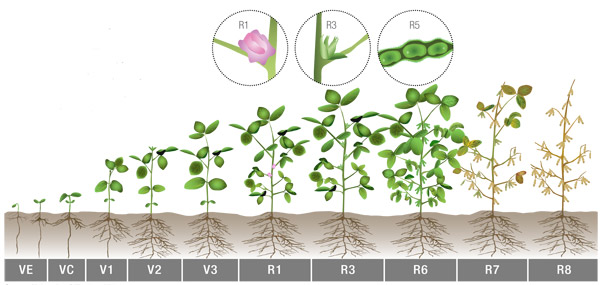